# Utilisation de R Markdown

# 1 Prise en main de R Markdown

## 1.1 Création du fichier rmd

Dans RStudio, vous pouvez faire Fichier/Nouveau fichier/R Markdown …

Ensuite la fenêtre ci-dessous apparaît

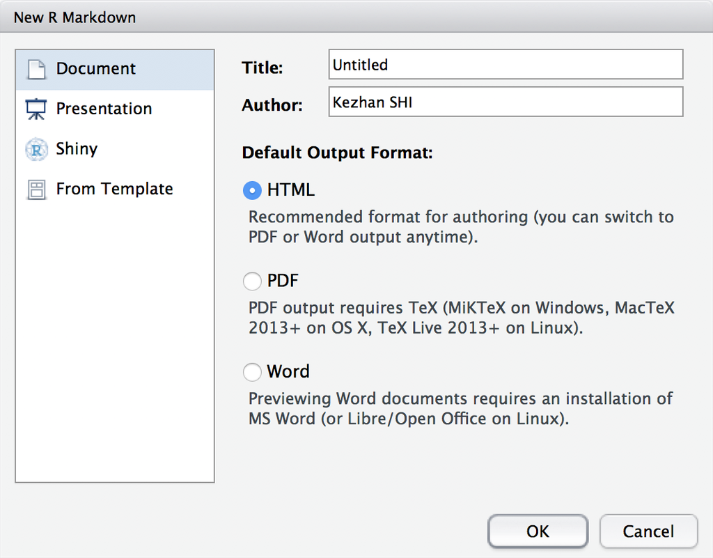

Vous pouvez choisir différents types de sortie. Dans un premier temps, on va choisir un document html, comme ci-dessous.

Vous pouvez saisir le titre du document et le nom d’auteur.

## 1.2 Contenu du fichier

Dans le fichier, vous pouvez voir qu’il y a déjà des exemple de textes et de codes. Il y a trois types de zones

- En-tête: une fois en haut du fichier pour préciser des informations générales liées au fichier
- Blocs de codes R (en anglais ce sont des chunks): **C’est là où vous allez programmer en R**
- Markdown: de façon simpliste, on peut considérer que ce sont des commentaires de votre programme.

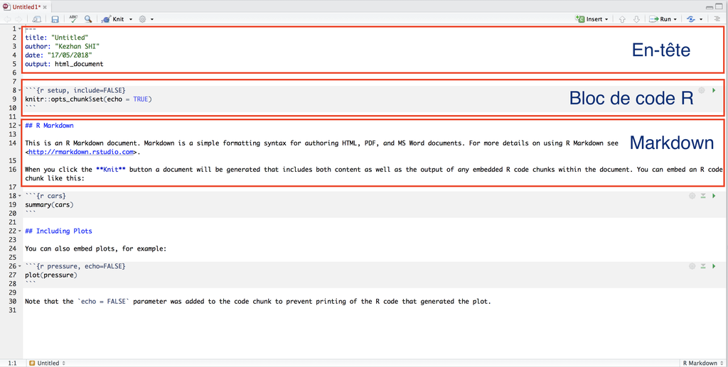